# Kollinearität

Der gesamte Code, den du hier findest, kann von dir 1:1 in R umgesetzt werden. Die größte Lernwirkung hat diese Einführung, wenn du möglichst alles einmal selbst in R durchführst.

# 01 Vorbereitungen

Bevor wir loslegen können, müssen wir die Packages laden, die wir für unser Vorhaben benötigen. Zunächst ist das nur das `SfL` Package. Falls du dieses noch nicht geladen hast, hole dies nun nach:

```r
library(SfL)
```

Nun laden wir die Datensätze, die wir nutzen werden:

```r
data(data_s)
data(data_z)
```

# 02 Ausschlussverfahren

Im Folgenden stellen wir den Vorgang dar, der auch im Theorieteil enthalten war. D.h. wir schließen Kollinearität als ein Problem für unser späteres Modell aus, indem wir zuvor Korrelationen feststellen und durch Vergleich und Ausschluss Variablen aussortieren.

Die folgenden Variablen möchten wir in unser Modell aufnehmen:

`item`, `speaker`, `gender`, `typeOfS`, `folSeg`, `slideNumber`, `transcription`, `baseDur`, `biphoneProbSum`, `biphoneProbSumBin`, `age`, `location`, `monoMultilingual`, `speakingRate`, `pauseDur`, `pauseBin`, `folType`, `preC`

Daher müssen wir auch all diese Variablen auf gegenseitige Korrelation untersuchen. Da dies in einzelnen Gegenüberstellungen viel Zeit beanspruchen würde, nutzen wir den `correlation_matrix` Befehl aus dem `SfL` Package.

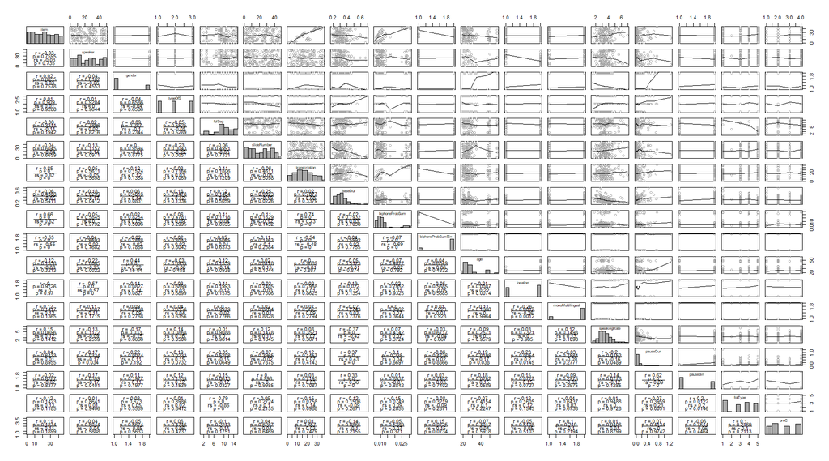

```r
correlation_matrix(data = data_s, variables = c("item", "speaker", "bsex", "typeOfS", "folSeg", "slideNumber", "transcription", "baseDur", "biphoneProbSum", "biphoneProbSumBin", "age", "location", "monoMultilingual", "speakingRate", "pauseDur", "pauseBin", "folType", "preC"))
```

Wir finden erneut die starken Korrelationen, die auch in den Slides enthalten sind:

- `item` vs. `transcription`
- `item` vs. `biphoneProbSum`
- `item` vs. `biphoneProbSumBin`
- `speaker` vs. `location`
- `folSeg` vs. `folType`
- `transcription` vs. `biphoneProbSum`
- `biphoneProbSum` vs. `biphoneProbSumBin`
- `pauseDur` vs. `pauseBin`

Nun erstellen wir nach und nach simple Modelle, jeweils eines pro Variable. Diese haben die Form eines Multiplen Linearen Modells. Diese Modelle werden dann anschließend vergleichen.

Damit der Vorgang nicht zu unübersichtlich wird, nutzen wir hierzu die `predictor_competition` Funktion:

```r
predictor_competition(data = data_s,
                      dependent = "sDurLog",
                      independent1 = "biphoneProbSum",
                      independent2 = "biphoneProbSumBin")
```

```
Analysis of Variance Table

Model 1: sDurLog ~ biphoneProbSum
Model 2: sDurLog ~ biphoneProbSumBin
  Res.Df    RSS Df Sum of Sq F Pr(>F)
1    148 23.937
2    148 24.264  0  -0.32695
```

## Aufgaben

Führe nun die weiteren Vergleiche durch. Halte dabei fest, welche Variable gewinnt.

**Lösung**

Welche Variablen gewinnen (sollten), siehst du in den Slides:

```r
open_exercise(11, 2023, "hannover")
```

# 03 Principal Component Analysis

Das in dieser Einführung genutzte Datenset modelliert die Dauer von /s/, ganz ähnlich dem Datenset, das wir bereits als `data_s` kennen. Die Variablen zur Vorhersage der /s/-Dauern sind teils andere; alle Werte sind frei erfunden.

Der Datensatz sieht wie folgt aus:

|  | Word | Affix | sDur | sDurLog | speechrate_1 | speechrate_2 | speechrate_3 | wordDur | baseDur | frequency1 | frequency2 | frequency3 | googleFrequency | reactionTime |
| --- | --- | --- | --- | --- | --- | --- | --- | --- | --- | --- | --- | --- | --- | --- |
| 1 | bloufs | PL | 0.12894 | -2.048408099 | 0.999993668 | 0.999993668 | 0.999993668 | 4.056037896 | 0.089442992 | 0.839009404 | 1 | 4.775081928 | 0 | 5.555555556 |
| 2 | bloufs | PL | 0.11313 | -2.179217679 | 0.999993668 | 0.999993668 | 0.999993668 | 4.056037896 | 0.089442992 | 0.839009404 | 1 | 4.775081928 | 0 | 5.555555556 |
| 3 | bloufs | PL | 0.11202 | -2.189077852 | 0.999993668 | 0.999993668 | 0.999993668 | 4.056037896 | 0.089442992 | 0.839009404 | 1 | 4.775081928 | 0 | 5.555555556 |
| 4 | bloufs | PL | 0.11968 | -2.122933765 | 0.999993668 | 0.999993668 | 0.999993668 | 4.056037896 | 0.089442992 | 0.839009404 | 1 | 4.775081928 | 0 | 5.555555556 |
| 5 | bloufs | PL | 0.16231 | -1.818247192 | 0.999993668 | 0.999993668 | 0.999993668 | 4.056037896 | 0.089442992 | 0.839009404 | 1 | 4.775081928 | 0 | 5.555555556 |
| 6 | bloufs | PL | 0.0846 | -2.469821012 | 0.999993668 | 0.999993668 | 0.999993668 | 4.056037896 | 0.089442992 | 0.839009404 | 1 | 4.775081928 | 0 | 5.555555556 |
| 7 | bloufs | PL | 0.15952 | -1.835585973 | 0.999993668 | 0.999993668 | 0.999993668 | 4.056037896 | 0.089442992 | 0.839009404 | 1 | 4.775081928 | 0 | 5.555555556 |
| 8 | bloufs | PL | 0.17139 | -1.763813618 | 0.999993668 | 0.999993668 | 0.999993668 | 4.056037896 | 0.089442992 | 0.839009404 | 1 | 4.775081928 | 0 | 5.555555556 |
| 9 | bloufs | PL | 0.09866 | -2.316075683 | 0.999993668 | 0.999993668 | 0.999993668 | 4.056037896 | 0.089442992 | 0.839009404 | 1 | 4.775081928 | 0 | 5.555555556 |
| 10 | bloufs | PL | 0.13834 | -1.978040856 | 0.999993668 | 0.999993668 | 0.999993668 | 4.056037896 | 0.089442992 | 0.839009404 | 1 | 4.775081928 | 0 | 5.555555556 |

[output cut: 643 more lines]

## Korrelationen checken

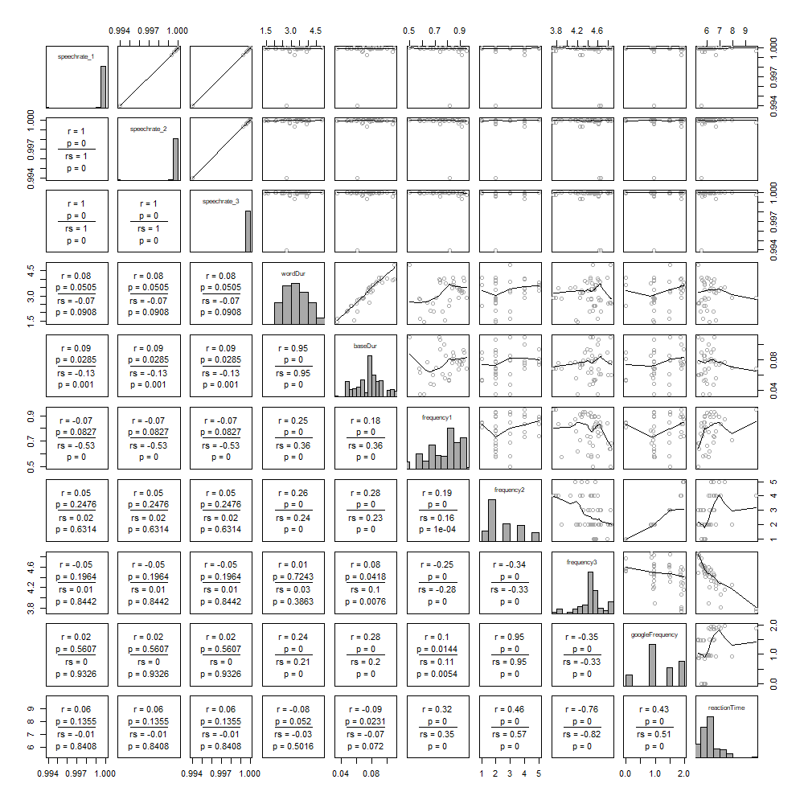

```r
correlation_matrix(data = data_z, variables = c("speechrate_1","speechrate_2","speechrate_3","wordDur","baseDur","frequency1","frequency2",
                     "frequency3","googleFrequency","reactionTime"))
```

- `speechrate1` vs. `speechrate2`, $\rho=1$
- `speechrate1` vs. `speechrate3`, $\rho=1$
- `speechrate2` vs. `speechrate3`, $\rho=1$
- `wordDur` vs. `baseDur`, $\rho=0.95$
- `frequency2` vs. `googleFrequency`, $\rho=0.95$
- `frequency3` vs. `reactionTime`, $\rho=-0.76$

Alle Variablen, die Teil einer solchen starken Korrelation sind, werden im nächsten Schritt in den *Topf* der PCA geworfen.

## Die PCA

Damit wir Kollinearitätsproblemen in unseren Modells später aus dem Weg gehen, nutzen wir nun eine Principal Component Analysis um die stark korrelierten Variablen zu neuen Variablen zu kombinieren. Diese neuen Variablen sind dann nicht mehr miteinander korreliert.

### Durchführung der PCA

Als erstes extrahieren wir die betroffenen Variablen aus dem ursprünglichen Datenset und erstellen aus diesen ein neues:

```r
pca.data1 <- data_z[colnames(data_z)=="speechrate1"]
pca.data2 <- data_z[colnames(data_z)=="speechrate2"]
pca.data3 <- data_z[colnames(data_z)=="speechrate3"]
pca.data4 <- data_z[colnames(data_z)=="wordDur"]
pca.data5 <- data_z[colnames(data_z)=="baseDur"]
pca.data6 <- data_z[colnames(data_z)=="frequency2"]
pca.data7 <- data_z[colnames(data_z)=="googleFrequency"]
pca.data8 <- data_z[colnames(data_z)=="frequency3"]
pca.data9 <- data_z[colnames(data_z)=="reactionTime"]

pca.data <- cbind(pca.data1,
                  pca.data2,
                  pca.data3,
                  pca.data4,
                  pca.data5,
                  pca.data6,
                  pca.data7,
                  pca.data8,
                  pca.data9)
```

Dann können wir mit der `princomp` Funktion von R die PCA durchführen lassen:

```r
pc <- princomp(pca.data, cor=TRUE, score=TRUE)
```

Nun müssen wir uns überlegen, wie viele der neuen Variablen (= Komponenten) wir im Anschluss behalten möchten. Hierfür gibt es einige Kriterien, denen man folgen kann. Eine Auswahl dieser lautet wie folgt:

1. Die s.g. *Eigenvalue* der jeweiligen Komponente muss größer als $1$ sein. Nur Komponenten mit einer Eigenvalue von mehr als $1$ erklären mehr Varianz in den Daten als dass sie verursachen.
2. Gemeinsam sollten die Komponenten, die man behält, circa $80\%$ der Varianz im Datenset erklären.
3. Nur Komponenten, die (relativ) stark mit ursprünglichen Variablen korreliert sind, sind auch interpretierbar. Eine neue Variable, die nicht interpretierbar ist, ist auch nicht nützlich, und sollte deshalb nicht behalten werden.

Schauen wir uns zuerst die *Eigenvalues* an (1. Spalte):

```r
# load package to extract Eigenvalues
library("factoextra")

# extract Eigenvalues
get_eigenvalue(pc)
```

```
      eigenvalue variance.percent cumulative.variance.percent
Dim.1 2.78935312       46.4892186                    46.48922
Dim.2 2.00939271       33.4898785                    79.97910
Dim.3 0.87353479       14.5589132                    94.53801
Dim.4 0.22853759        3.8089599                    98.34697
Dim.5 0.06921791        1.1536318                    99.50060
Dim.6 0.02996387        0.4993979                   100.00000
```

Wir sehen, dass nur Komponente 1 und 2 eine *Eigenvalue* haben, die größer als $1$ ist. Daher liegt es nahe, nur diese neuen Variablen zu behalten.

Schauen wir uns nun an, wie viel Prozent der Varianz die Komponenten gemeinsam erklären (3. Spalte):

```r
# load package to extract Eigenvalues
library("factoextra")

# extract Eigenvalues
get_eigenvalue(pc)
```

```
      eigenvalue variance.percent cumulative.variance.percent
Dim.1 2.78935312       46.4892186                    46.48922
Dim.2 2.00939271       33.4898785                    79.97910
Dim.3 0.87353479       14.5589132                    94.53801
Dim.4 0.22853759        3.8089599                    98.34697
Dim.5 0.06921791        1.1536318                    99.50060
Dim.6 0.02996387        0.4993979                   100.00000
```

Wir sehen, dass Komponente 1 und 2 gemeinsam circa $80\%$ der Varianz erklären. Unserem zuvor genannten Wunschwert von eben $80\%$ sind wir damit schon extrem nahe.

Zuletzt betrachten wir die Komponenten daraufhin, ob sie starke Korrelationen mit den ursprünglichen Variablen aufweisen. Hierzu schauen wir uns die s.g. *Loadings* der neuen Variablen an:

```r
pc$loadings
```

```
Loadings:
                Comp.1 Comp.2 Comp.3 Comp.4 Comp.5 Comp.6
wordDur          0.275  0.580  0.320         0.489  0.496
baseDur          0.276  0.595  0.237 -0.115 -0.511 -0.490
frequency2       0.534        -0.450         0.521 -0.489
googleFrequency  0.528        -0.470  0.152 -0.477  0.500
frequency3      -0.360  0.379 -0.538 -0.650         0.120
reactionTime     0.394 -0.406  0.360 -0.735         0.101

               Comp.1 Comp.2 Comp.3 Comp.4 Comp.5 Comp.6
SS loadings     1.000  1.000  1.000  1.000  1.000  1.000
Proportion Var  0.167  0.167  0.167  0.167  0.167  0.167
Cumulative Var  0.167  0.333  0.500  0.667  0.833  1.000
```

Hier stellen wir fest, dass alle Komponenten starke Korrelationen aufweisen. Dies erkennen wir daran, dass in allen Spalten Werte ab ca. $0.5$ bzw. unter ca. $-0.5$ zu finden sind.

Fassen wir die Funde nach allen drei Kriterien zusammen, so zeigt sich nun folgendes Bild:

1. Komponente 1 + 2 haben *Eigenvalues* über $1$.
2. Komponente 1 + 2 erklären gemeinsam ca. $80\%$ der Varianz.
3. Komponenten 1 bis 6 sind stark mit ursprünglichen Variablen korreliert.

Die ausgewählten Komponenten fügen wir nun als neue Variablen zu unserem ursprünglichen Datenset hinzu, damit wir alles in einem haben:

```r
pcframe <- as.data.frame(pc$scores)
pcframe <- pcframe[1:3]

names(pcframe)[names(pcframe) == "Comp.1"] <- "Komponente1"
names(pcframe)[names(pcframe) == "Comp.2"] <- "Komponente2"

data <- cbind(data_z, pcframe)
```

### Die neuen Variablen

Nun müssen wir noch versuchen zu verstehen, was unsere neuen zwei Variablen konzeptionell bedeuten. Hierzu rufen wir uns die *Loadings* erneut in Erinnerung:

```r
pc$loadings
```

```
Loadings:
                Comp.1 Comp.2 Comp.3 Comp.4 Comp.5 Comp.6
wordDur          0.275  0.580  0.320         0.489  0.496
baseDur          0.276  0.595  0.237 -0.115 -0.511 -0.490
frequency2       0.534        -0.450         0.521 -0.489
googleFrequency  0.528        -0.470  0.152 -0.477  0.500
frequency3      -0.360  0.379 -0.538 -0.650         0.120
reactionTime     0.394 -0.406  0.360 -0.735         0.101

               Comp.1 Comp.2 Comp.3 Comp.4 Comp.5 Comp.6
SS loadings     1.000  1.000  1.000  1.000  1.000  1.000
Proportion Var  0.167  0.167  0.167  0.167  0.167  0.167
Cumulative Var  0.167  0.333  0.500  0.667  0.833  1.000
```

Für unsere zwei ausgewählten Komponenten (die ersten zwei) betrachten wir nun die Werte, die eine starke Korrelation nahelegen. Diese lauten:

- für `Komponente1`: `frequency2` & `googleFrequency`
- für `Komponente2`: `wordDur` & `baseDur`

Zu den jeweils anderen ursprünglichen Variablen zeigen die beiden Komponenten zwar auch Korrelationen, diese sind allerdings niedriger. Dort, wo gar keine Zahl gegeben ist, ist $\rho=0$, d.h. es gibt keine Korrelation.

### Komponente 1

`Komponente1` ist stark mit `frequency2` und `googleFrequency` korreliert. D.h. ihre konzeptionelle Bedeutung speist sich vor allem aus den Bedeutungen dieser beiden Variablen.

`frequency2` beschreibt die Häufigkeit des Wortes in einem Korpus, `googleFrequency` ist die Menge der Hits eines Wortes bei einer einfachen Google-Suche.

Gemeinsam kann man also abstrahiert sagen, dass `Komponente1` die Häufigkeit des Vorkommens eines Wortes beschreibt.

Zeigt diese `Komponente1` später in Regressionsmodellen einen

- positiven Einfluss, bedeutet dies, dass höhere Frequenzen zu längeren /s/ Dauern führen.
- negativen Einfluss, bedeutet dies, dass höhere Frequenzen zu kürzeren /s/ Dauern führen.

### Komponente 2

`Komponente2` ist stark mit `wordDur` und `baseDur` korreliert. D.h. ihre konzeptionelle Bedeutung speist sich vor allem aus den Bedeutungen dieser beiden Variablen.

`wordDur` beschreibt die gesamte Wortdauer, `baseDur` die Dauer des Wortes ohne finales /s/.

Gemeinsam kann mn also abstrahiert sagen, dass `Komponente2` die Dauer des Wortes (mit und ohne /s/) beschreibt.

Zeigt diese `Komponente2` später in Regressionsmodellen einen

- positiven Einfluss, bedeutet dies, dass längere Wortdauern zu längeren /s/ Dauern führen.
- negativen Einfluss, bedeutet dies, dass längere Wortdauern zu kürzeren /s/ Dauern führen.

## Weiteres Vorgehen

Mit den gefundenen neuen Variablen kann nun genau so gearbeitet werden wie mit den Variablen, die im ursprünglichen Datenset stecken, die aber nicht Teil der PCA waren.

Die Variablen, die zwar Teil der PCA waren, bei der Deutung der neuen Variablen jedoch keine große Rolle spielen, werden im weiteren Verlauf nicht genutzt.